# IODS course project

# Chapter 5, Dimensionality reduction techniques

## Libraries

```r
#needed libraries
library(tidyverse)
library(dplyr)
library(corrplot)
library(GGally)
library(FactoMineR)
library(tidyr)
```

## The data

First it is needed to read in the data and modify it, so that country names are row names.

```r
#read in the data
data <- read_csv("data/human.csv")
#change the countries to row names
data <- column_to_rownames(data, "Country")

#structure and dimensions
str(data)
```

```
## 'data.frame':    155 obs. of  8 variables:
##  $ Edu2.FM  : num  1.007 0.997 0.983 0.989 0.969 ...
##  $ Labo.FM  : num  0.891 0.819 0.825 0.884 0.829 ...
##  $ Life.Exp : num  81.6 82.4 83 80.2 81.6 80.9 80.9 79.1 82 81.8 ...
##  $ Edu.Exp  : num  17.5 20.2 15.8 18.7 17.9 16.5 18.6 16.5 15.9 19.2 ...
##  $ GNI      : num  64992 42261 56431 44025 45435 ...
##  $ Mat.Mor  : num  4 6 6 5 6 7 9 28 11 8 ...
##  $ Ado.Birth: num  7.8 12.1 1.9 5.1 6.2 3.8 8.2 31 14.5 25.3 ...
##  $ Parli.F  : num  39.6 30.5 28.5 38 36.9 36.9 19.9 19.4 28.2 31.4 ...
```

```r
dim(data)
```

```
## [1] 155   8
```

```r
#Summary of the variables in the data
summary(data)
```

```
##     Edu2.FM          Labo.FM          Life.Exp        Edu.Exp
##  Min.   :0.1717   Min.   :0.1857   Min.   :49.00   Min.   : 5.40
##  1st Qu.:0.7264   1st Qu.:0.5984   1st Qu.:66.30   1st Qu.:11.25
##  Median :0.9375   Median :0.7535   Median :74.20   Median :13.50
##  Mean   :0.8529   Mean   :0.7074   Mean   :71.65   Mean   :13.18
##  3rd Qu.:0.9968   3rd Qu.:0.8535   3rd Qu.:77.25   3rd Qu.:15.20
##  Max.   :1.4967   Max.   :1.0380   Max.   :83.50   Max.   :20.20
##       GNI            Mat.Mor         Ado.Birth         Parli.F
##  Min.   :   581   Min.   :   1.0   Min.   :  0.60   Min.   : 0.00
##  1st Qu.:  4198   1st Qu.:  11.5   1st Qu.: 12.65   1st Qu.:12.40
##  Median : 12040   Median :  49.0   Median : 33.60   Median :19.30
##  Mean   : 17628   Mean   : 149.1   Mean   : 47.16   Mean   :20.91
##  3rd Qu.: 24512   3rd Qu.: 190.0   3rd Qu.: 71.95   3rd Qu.:27.95
##  Max.   :123124   Max.   :1100.0   Max.   :204.80   Max.   :57.50
```

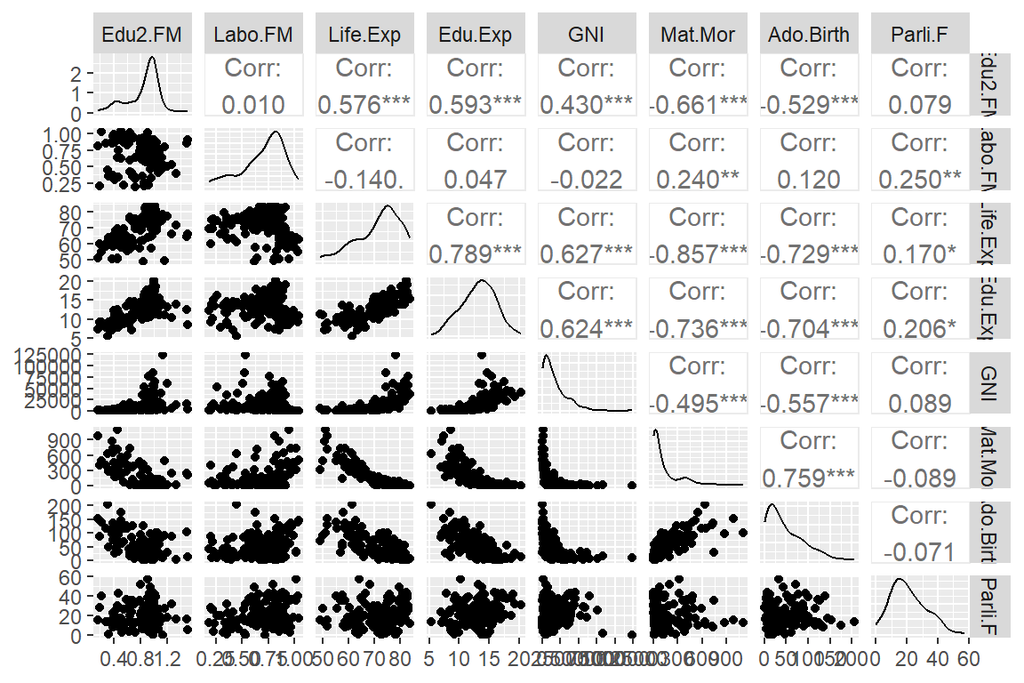

```r
#Visualisation of the variables
ggpairs(data,progress = FALSE )
```

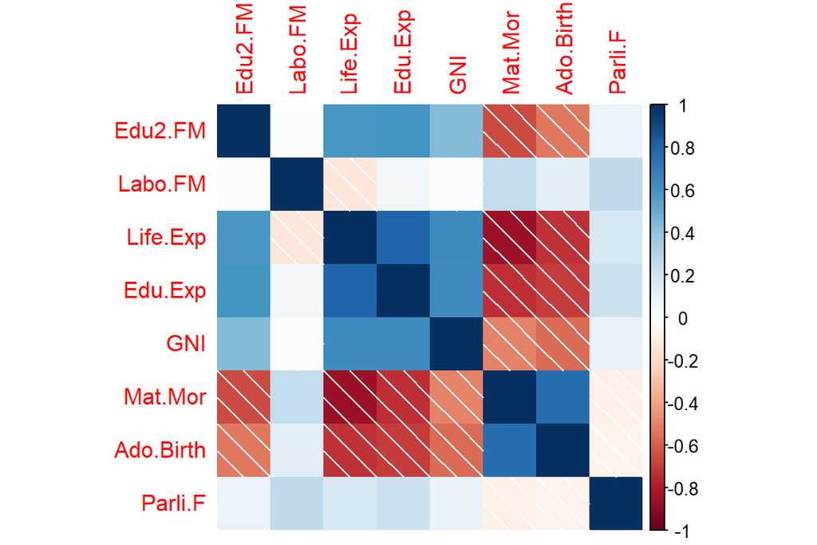

```r
#correlation visualisation
cor_matrix <- cor(data) %>% round(digits = 2)
corrplot(cor_matrix, method="shade")
```

The data contains 155 rows and 8 columns, and row names are different countries. Some details for the variables:

1. Edu2.FM = Ratio of female and male populations with secondary education in each country, numerical value between 0.17-1.49.
2. Labo.FM = Ratio of labor force participation of females and males in each country, numerical value between 0.18-1.03
3. Life.Exp = Numeric variable that indicates Life Expectancy at Birth, values between 49-83.5 years.
4. Edu.Exp = Numeric variable that indicates Expected Years of Education, value between 5.4-20.20
5. GNI = Gross National Income (GNI) per Capita, numeric variable between 581-123 124
6. Mat.Mor = Maternal Mortality Ratio, numeric variable form 1 to 1100
7. Ado.Birth = Adolescent Birth Rate, numeric variable between 0.6-204.80
8. Parli.F = Percent Representation in Parliament, numeric variable from 0 to 57.5

In the data there is notable correlations between the variables, if the data is used, for example, in linear regression, this should be taken into account when choosing the variables. For example the correlation between life expectancy and maternal mortality, is -0.8, but it is understandable that the life expectancy gets lower when the maternal mortality is high. Data for GNI, Mat.Mor, Ado.birth and Parli.F is skewed to the right, i.e. in most countries the values are at the lower end of the scale. Lado.FM and Life.Exp on the other hand are more left skewed, meaning that most countries have bigger values on those categories.

## Principal component analysis

First PCA analysis is made for non-standardized data.

```r
#PCA analysis
pca_non_standard <- prcomp(data)

#Safe the summary of the PCA analysis
s_NS <- summary(pca_non_standard)

#print out the summary
s_NS
```

```
## Importance of components:
##                              PC1      PC2   PC3   PC4   PC5   PC6    PC7    PC8
## Standard deviation     1.854e+04 185.5219 25.19 11.45 3.766 1.566 0.1912 0.1591
## Proportion of Variance 9.999e-01   0.0001  0.00  0.00 0.000 0.000 0.0000 0.0000
## Cumulative Proportion  9.999e-01   1.0000  1.00  1.00 1.000 1.000 1.0000 1.0000
```

```r
#Presentages of the pca analysis
pca_pr_NS <- round(100*s_NS$importance[2, ], digits = 1)

#print out the presentages
pca_pr_NS
```

```
## PC1 PC2 PC3 PC4 PC5 PC6 PC7 PC8
## 100   0   0   0   0   0   0   0
```

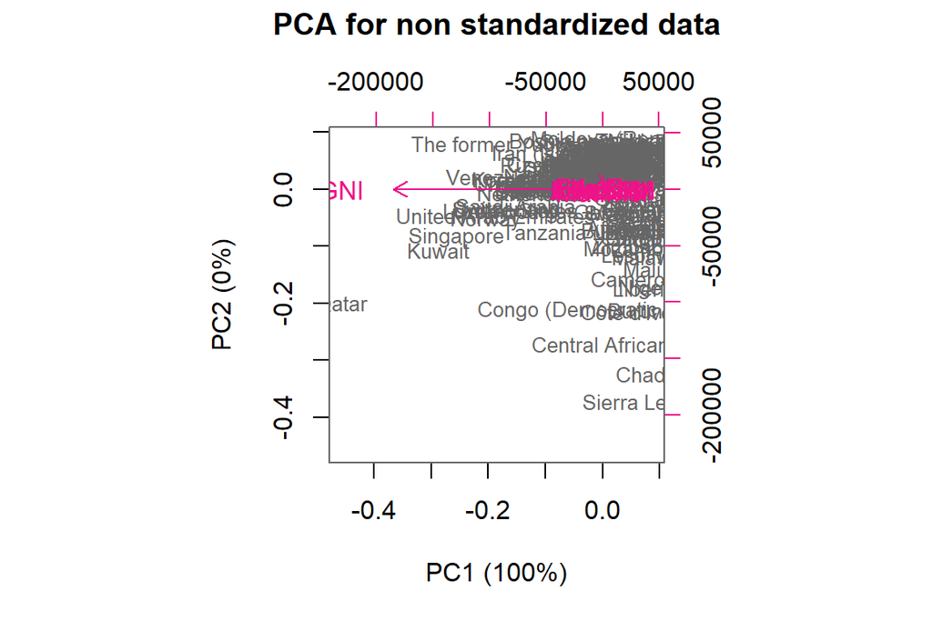

```
## integer(0)
```

```r
#create object that helps with the labesl
pc_lab_NS <- paste0(names(pca_pr_NS), " (", pca_pr_NS, "%)")

# draw a biplot
biplot(pca_non_standard, cex = c(0.8, 1), col = c("grey40", "deeppink2"), xlab = pc_lab_NS[1], ylab = pc_lab_NS[2]) + title("PCA for non standardized data", line = 3)
```

Because the data is not standardized the results are not very good, or easily interpretable. (More interpretations will come later). Lets see how the results change when the data is standardized. Standardizing the data modifies it so that all the mean values became 0 and the data varies on both sides of it. The values contained in the different columns of the data are thus better compared to each other.

```r
#standardize the data
data_std <- scale(data)

#how the data looks now?
summary(data_std)
```

```
##     Edu2.FM           Labo.FM           Life.Exp          Edu.Exp
##  Min.   :-2.8189   Min.   :-2.6247   Min.   :-2.7188   Min.   :-2.7378
##  1st Qu.:-0.5233   1st Qu.:-0.5484   1st Qu.:-0.6425   1st Qu.:-0.6782
##  Median : 0.3503   Median : 0.2316   Median : 0.3056   Median : 0.1140
##  Mean   : 0.0000   Mean   : 0.0000   Mean   : 0.0000   Mean   : 0.0000
##  3rd Qu.: 0.5958   3rd Qu.: 0.7350   3rd Qu.: 0.6717   3rd Qu.: 0.7126
##  Max.   : 2.6646   Max.   : 1.6632   Max.   : 1.4218   Max.   : 2.4730
##       GNI             Mat.Mor          Ado.Birth          Parli.F
##  Min.   :-0.9193   Min.   :-0.6992   Min.   :-1.1325   Min.   :-1.8203
##  1st Qu.:-0.7243   1st Qu.:-0.6496   1st Qu.:-0.8394   1st Qu.:-0.7409
##  Median :-0.3013   Median :-0.4726   Median :-0.3298   Median :-0.1403
##  Mean   : 0.0000   Mean   : 0.0000   Mean   : 0.0000   Mean   : 0.0000
##  3rd Qu.: 0.3712   3rd Qu.: 0.1932   3rd Qu.: 0.6030   3rd Qu.: 0.6127
##  Max.   : 5.6890   Max.   : 4.4899   Max.   : 3.8344   Max.   : 3.1850
```

```r
#Make the PCA again
pca_std  <- prcomp(data_std)

#Safe the summary of the PCA analysis
s <- summary(pca_std)

#print out the summary
s
```

```
## Importance of components:
##                           PC1    PC2     PC3     PC4     PC5     PC6     PC7
## Standard deviation     2.0708 1.1397 0.87505 0.77886 0.66196 0.53631 0.45900
## Proportion of Variance 0.5361 0.1624 0.09571 0.07583 0.05477 0.03595 0.02634
## Cumulative Proportion  0.5361 0.6984 0.79413 0.86996 0.92473 0.96069 0.98702
##                            PC8
## Standard deviation     0.32224
## Proportion of Variance 0.01298
## Cumulative Proportion  1.00000
```

```r
#Presentages of the pca analysis
pca_pr <- round(100*s$importance[2, ], digits = 1)

#print out the presentages
pca_pr
```

```
##  PC1  PC2  PC3  PC4  PC5  PC6  PC7  PC8
## 53.6 16.2  9.6  7.6  5.5  3.6  2.6  1.3
```

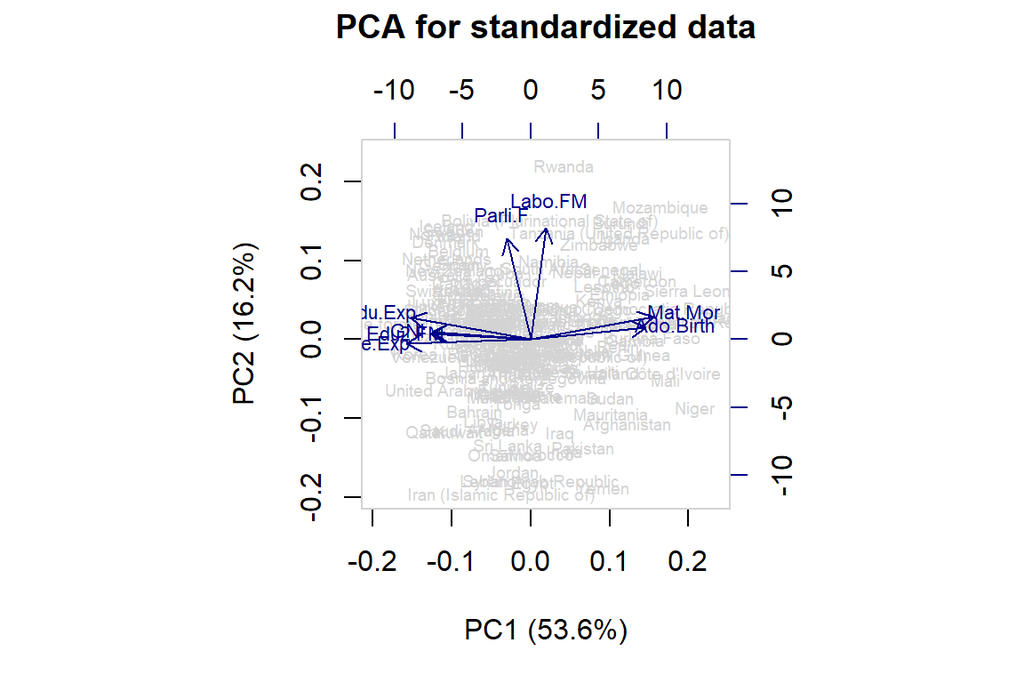

```
## integer(0)
```

```r
#create object that helps with the labesl
pc_lab <- paste0(names(pca_pr), " (", pca_pr, "%)")

# draw a biplot
biplot(pca_std, cex = c(0.6, 0.7), col = c("lightgrey", "darkblue"), xlab = pc_lab[1], ylab = pc_lab[2]) + title("PCA for standardized data", line = 3)
```

Now the results are more clear. PCA analysis tries to create new uncorrelated variables that explain as much as possible for the variation in the original data, to create lower-dimensional summary of the original data. For the analysis made with non standardized data, the analysis has not been able to really create those variables, because as a result the first variable (PC1) is explaining 100% of the variation and because this the second variable (PC2) is explaining 0%. Only really visible original variable in the plot is GNI (Gross National Income per capita), probably because its values are so much higher than other variables. Because of this it is quite impossible to say anything specific about the results themselves.

PCA analysis made for standardized data is much more realistic, and this time the first variable is explaining 53.6% of the variation and second 16.2%. In the results the Labo (Ratio of labor force participation of females and males in each country) can be used to describe how equal the community is from the point of view of women’s employment. Parli (Percent Representation in Parliament) variable arrow on the other hand is implying what kind of influence opportunities women have. Together these original variable arrows are pointing on somewhat same direction making a clear distinction between the equality in different countries. Women’s participation in working life and politics are also implications of women’s ability to decide on their own lives and public activities. In the countries that are placed on the opposite side of these arrows women could be mostly in home and taking care of children, and all the important decisions are made by other (possibly male) relatives. Countries located near the Mat.Mor (Maternal Mortality Ratio) and Ado.Birth (Adolescent Birth Rate) arrows can be used to indicate countries where mothers are younger and where possibly the health care is poorer or not easily available. Also due to younger age of mothers it is more likely to get possible deadly complications when giving birth. It is also possible that in those countries the contraceptives are not so easily available. In the opposite side of these variables are countries where education rates and life expectancy are higher. This indicates that in the countries where education is more available (especially for women) the teenage pregnancies are rarer, probably due to better sex education and different life choice options.

Overall the PCA analysis is describing the gender equality in different countries and how it is shown in different areas of life. In the PCA analysis done with non-standardized data the first variable is mostly based on the Gross National Income and all of the deviation is created based on that. In the standardized analysis the first variable (that explains 53% of the variation) is created from positive influence of level of education and educational opportunities and negative influence of teenage pregnancies and maternal mortality, to define the location of different countries. The second variable (that explains 16%) is based on the influence of labor force and women participation of parliament, and the new variable describes the gender equality in different countries.

## Multiple Correspondence Analysis

First read in the tea data:

```r
#read in the data
tea <- read.csv("https://raw.githubusercontent.com/KimmoVehkalahti/Helsinki-Open-Data-Science/master/datasets/tea.csv", stringsAsFactors = TRUE)

#visually check the data
#View(tea) (i change this to comment because it was "problem" when knitting)

#dimensions and stucture of the data
str(tea)
```

```
## 'data.frame':    300 obs. of  36 variables:
##  $ breakfast       : Factor w/ 2 levels "breakfast","Not.breakfast": 1 1 2 2 1 2 1 2 1 1 ...
##  $ tea.time        : Factor w/ 2 levels "Not.tea time",..: 1 1 2 1 1 1 2 2 2 1 ...
##  $ evening         : Factor w/ 2 levels "evening","Not.evening": 2 2 1 2 1 2 2 1 2 1 ...
##  $ lunch           : Factor w/ 2 levels "lunch","Not.lunch": 2 2 2 2 2 2 2 2 2 2 ...
##  $ dinner          : Factor w/ 2 levels "dinner","Not.dinner": 2 2 1 1 2 1 2 2 2 2 ...
##  $ always          : Factor w/ 2 levels "always","Not.always": 2 2 2 2 1 2 2 2 2 2 ...
##  $ home            : Factor w/ 2 levels "home","Not.home": 1 1 1 1 1 1 1 1 1 1 ...
##  $ work            : Factor w/ 2 levels "Not.work","work": 1 1 2 1 1 1 1 1 1 1 ...
##  $ tearoom         : Factor w/ 2 levels "Not.tearoom",..: 1 1 1 1 1 1 1 1 1 2 ...
##  $ friends         : Factor w/ 2 levels "friends","Not.friends": 2 2 1 2 2 2 1 2 2 2 ...
##  $ resto           : Factor w/ 2 levels "Not.resto","resto": 1 1 2 1 1 1 1 1 1 1 ...
##  $ pub             : Factor w/ 2 levels "Not.pub","pub": 1 1 1 1 1 1 1 1 1 1 ...
##  $ Tea             : Factor w/ 3 levels "black","Earl Grey",..: 1 1 2 2 2 2 2 1 2 1 ...
##  $ How             : Factor w/ 4 levels "alone","lemon",..: 1 3 1 1 1 1 1 3 3 1 ...
```

[output cut: 22 more lines]

```r
dim(tea)
```

```
## [1] 300  36
```

```r
#there is 300 observations and 36 different variables
```

Because there is so many variables in the data, i chose to select only few variables in the further analysis. I chose to use frequency (how often tea is drank), age (age group of the person answering the question), Tea (what kind of tea is persons drinking), Sugar (with or without sugar), tea.time (does the person have specific time for drinking tea), breakfast (does person drink tea in breakfast), lunch (does person drink tea in lunch), dinner (does person drink tea in dinner) and work (do people drink tea in work or not).

```r
#vector that includes the chosen variables
keep_columns <- c("frequency", "age_Q", "Tea", "sugar", "tea.time", "breakfast", "work", "lunch", "dinner")

#create new data set for chosen variables
tea_time <- dplyr::select(tea, keep_columns)
#summary of the data
summary(tea_time)
```

```
##        frequency     age_Q           Tea           sugar             tea.time
##  +2/day     :127   +60  :38   black    : 74   No.sugar:155   Not.tea time:131
##  1 to 2/week: 44   15-24:92   Earl Grey:193   sugar   :145   tea time    :169
##  1/day      : 95   25-34:69   green    : 33
##  3 to 6/week: 34   35-44:40
##                    45-59:61
##          breakfast         work           lunch            dinner
##  breakfast    :144   Not.work:213   lunch    : 44   dinner    : 21
##  Not.breakfast:156   work    : 87   Not.lunch:256   Not.dinner:279
##
##
##
```

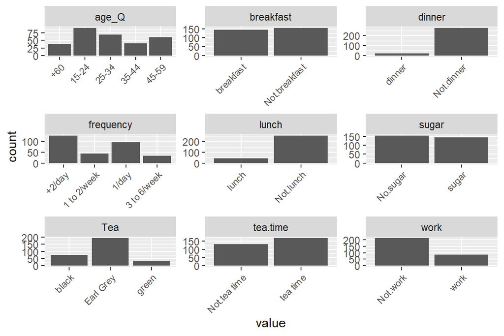

```r
# visualize the variables
library(ggplot2)
pivot_longer(tea_time, cols = everything()) %>%
  ggplot(aes(value)) + facet_wrap("name", scales = "free") +
  geom_bar() +
  theme(axis.text.x = element_text(angle = 45, hjust = 1, size = 8))
```

In the chosen variables the sugar and no sugar and breakfast and not breakfast drinkers are divided on somewhat equally, but there are more people who don’t drink tea in lunch or dinner than those who do. Most people’s drink choice is Earl Grey. People seem to drink tea mostly daily, either one or more than two cups. All the different age groups seem to be presented quite well, but there is slightly more people in the 15-24 age group than other groups. More people also don’t drink tea at work.

```r
#do the MCA analysis
mca <- MCA(tea_time, graph = FALSE)

# summary of the model
summary(mca)
```

```
##
## Call:
## MCA(X = tea_time, graph = FALSE)
##
##
## Eigenvalues
##                        Dim.1   Dim.2   Dim.3   Dim.4   Dim.5   Dim.6   Dim.7
## Variance               0.211   0.174   0.151   0.145   0.127   0.118   0.112
## % of var.             12.689  10.469   9.037   8.719   7.615   7.103   6.738
## Cumulative % of var.  12.689  23.157  32.194  40.913  48.528  55.631  62.369
##                        Dim.8   Dim.9  Dim.10  Dim.11  Dim.12  Dim.13  Dim.14
## Variance               0.104   0.100   0.091   0.074   0.073   0.066   0.063
## % of var.              6.234   5.980   5.442   4.433   4.399   3.933   3.783
## Cumulative % of var.  68.602  74.582  80.025  84.458  88.857  92.790  96.574
##                       Dim.15
## Variance               0.057
## % of var.              3.426
## Cumulative % of var. 100.000
##
## Individuals (the 10 first)
##                Dim.1    ctr   cos2    Dim.2    ctr   cos2    Dim.3    ctr
## 1           | -0.042  0.003  0.001 |  0.211  0.085  0.025 | -0.304  0.205
## 2           | -0.291  0.133  0.058 |  0.509  0.494  0.178 | -0.584  0.755
## 3           |  0.060  0.006  0.001 | -0.028  0.001  0.000 | -0.460  0.468
## 4           |  1.094  1.886  0.487 | -0.107  0.022  0.005 | -0.123  0.034
## 5           | -0.319  0.160  0.093 |  0.098  0.018  0.009 | -0.335  0.248
## 6           |  0.872  1.200  0.312 |  0.107  0.022  0.005 | -0.268  0.158
## 7           | -0.362  0.207  0.064 |  0.056  0.006  0.002 |  0.080  0.014
## 8           | -0.074  0.009  0.003 |  0.587  0.658  0.166 |  0.270  0.162
## 9           | -0.549  0.474  0.228 | -0.047  0.004  0.002 | -0.077  0.013
## 10          | -0.483  0.367  0.141 |  0.375  0.269  0.085 | -0.179  0.071
##               cos2
## 1            0.053 |
## 2            0.235 |
## 3            0.078 |
## 4            0.006 |
## 5            0.103 |
## 6            0.029 |
## 7            0.003 |
## 8            0.035 |
```

[output cut: 23 more lines]

```
## 35-44       -0.216  0.458  0.007 -1.464 |
## 45-59       -0.689  7.118  0.121 -6.018 |
## black        0.118  0.255  0.005  1.171 |
##
## Categorical variables (eta2)
##               Dim.1 Dim.2 Dim.3
## frequency   | 0.363 0.025 0.361 |
## age_Q       | 0.223 0.418 0.476 |
## Tea         | 0.151 0.515 0.037 |
## sugar       | 0.210 0.160 0.064 |
## tea.time    | 0.278 0.013 0.045 |
## breakfast   | 0.277 0.098 0.057 |
## work        | 0.060 0.266 0.100 |
## lunch       | 0.050 0.071 0.189 |
## dinner      | 0.291 0.005 0.027 |
```

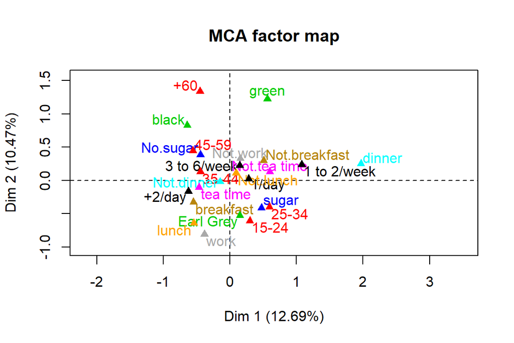

```r
# visualize MCA
plot(mca, invisible=c("ind"), graph.type = "classic", habillage = "quali")
```

In the MCA model with two-dimensional map, only 23% of the total inertia is explained, so there could be a need for more dimensions or further analysis. The first dimension is explaining a little bit under 13% and second little bit over 10%. Based on the visualization, the first variable is describing the different times people drink tea and second is describing the different types of tea drinking habits and age groups. Results of the analysis say that older people prefer to drink green or black tea and younger people drink Earl grey and possibly with sugar. Also older people might have a specific tea time, while younger people don’t have a specific tea drinking time. Also breakfast and dinner points are located quite far from each other so it could be argued that people how drink coffee in the morning don’t drink it in the evening and other way around. Also points for people who drink tea in the breakfast and people who drink more than 2 cups in a day are very close to each other. This means that people who drink morning tea probably drink tea more than two cups. Same thing is for lunch and work points, but that also can be caused by coincidence because people are usually in work by lunch time. Altogether i think that MCA is quite good tool for visual analysis of factor data, but it takes some time to get used to it.

# Chapter 6, Analysis of longitudinal data

## Libraries

All the libraries that will be needed in the codes later.

```r
library(tidyverse)
library(dplyr)
library(tidyr)
library(ggplot2)
library(lme4)
```

## Read in the data

Lets bring in the data that has been made in data wrangling part. Because R did not safe the information about factor variables it is needed to define them again.

```r
#Read in the data

BPRS <- read_csv("data/BPRS.csv")
RATS <- read_csv("data/RATS.csv")
#change variables to factors
BPRS$treatment <- as.factor(BPRS$treatment)
BPRS$subject <- as.factor(BPRS$subject)

RATS$Group <- as.factor(RATS$Group)
RATS$ID <- as.factor(RATS$ID)

#Structure of the data
str(BPRS)
```

```
## spc_tbl_ [360 × 5] (S3: spec_tbl_df/tbl_df/tbl/data.frame)
##  $ treatment: Factor w/ 2 levels "1","2": 1 1 1 1 1 1 1 1 1 1 ...
##  $ subject  : Factor w/ 20 levels "1","2","3","4",..: 1 2 3 4 5 6 7 8 9 10 ...
##  $ weeks    : chr [1:360] "week0" "week0" "week0" "week0" ...
##  $ bprs     : num [1:360] 42 58 54 55 72 48 71 30 41 57 ...
##  $ week     : num [1:360] 0 0 0 0 0 0 0 0 0 0 ...
##  - attr(*, "spec")=
##   .. cols(
##   ..   treatment = col_double(),
##   ..   subject = col_double(),
##   ..   weeks = col_character(),
##   ..   bprs = col_double(),
##   ..   week = col_double()
##   .. )
##  - attr(*, "problems")=<externalptr>
```

```r
str(RATS)
```

```
## spc_tbl_ [176 × 5] (S3: spec_tbl_df/tbl_df/tbl/data.frame)
##  $ ID    : Factor w/ 16 levels "1","2","3","4",..: 1 2 3 4 5 6 7 8 9 10 ...
##  $ Group : Factor w/ 3 levels "1","2","3": 1 1 1 1 1 1 1 1 2 2 ...
##  $ WD    : chr [1:176] "WD1" "WD1" "WD1" "WD1" ...
##  $ Weight: num [1:176] 240 225 245 260 255 260 275 245 410 405 ...
##  $ Time  : num [1:176] 1 1 1 1 1 1 1 1 1 1 ...
##  - attr(*, "spec")=
##   .. cols(
##   ..   ID = col_double(),
##   ..   Group = col_double(),
##   ..   WD = col_character(),
##   ..   Weight = col_double(),
##   ..   Time = col_double()
##   .. )
##  - attr(*, "problems")=<externalptr>
```

```r
#dimensions
dim(BPRS)
```

```
## [1] 360   5
```

```r
dim(RATS)
```

```
## [1] 176   5
```

```r
#summary
summary(BPRS)
```

```
##  treatment    subject       weeks                bprs            week
##  1:180     1      : 18   Length:360         Min.   :18.00   Min.   :0
##  2:180     2      : 18   Class :character   1st Qu.:27.00   1st Qu.:2
##            3      : 18   Mode  :character   Median :35.00   Median :4
##            4      : 18                      Mean   :37.66   Mean   :4
##            5      : 18                      3rd Qu.:43.00   3rd Qu.:6
##            6      : 18                      Max.   :95.00   Max.   :8
##            (Other):252
```

```r
summary(RATS)
```

```
##        ID      Group       WD                Weight           Time
##  1      : 11   1:88   Length:176         Min.   :225.0   Min.   : 1.00
##  2      : 11   2:44   Class :character   1st Qu.:267.0   1st Qu.:15.00
##  3      : 11   3:44   Mode  :character   Median :344.5   Median :36.00
##  4      : 11                             Mean   :384.5   Mean   :33.55
##  5      : 11                             3rd Qu.:511.2   3rd Qu.:50.00
##  6      : 11                             Max.   :628.0   Max.   :64.00
##  (Other):110
```

The BPRS data includes data from brief psychiatric rating scale, that was used to indicate how well two different treatments where working for 40 different male subjects (20 for group one and 20 for group 2) in 8 weeks study period. The data sets includes 5 variables: treatment (what treatment they were getting (factor value 1 or 2)), subject (factor value from 1 to 20 indicating the male subject), weeks (information about original week column where the data is from), bprs (results for the test) and week (week number). Overall there is 360 observations in those 5 columns. However, the important thing to note when processing the data, is that the different research subjects do not have a unique id code, but the id numbers are the same in both groups. So the group id is necessary when differentiating the results.

RATS data is from nutrition study where rats were put in three different groups. Each of those groups got different diets and the weight of each rat in the group was recorded weekly for 9 weeks. The data for RATS includes 5 variables: id (factor identification for the rat), group (factor identification about which group the rat is in), WD (information about original week column), weight (rats weight in grams) and time (the week number extracted from original WD information). Measurements where taken in once a week, but in week seven (in the data numbers 43 and 44) two measurements where taken.

## Analysis for RATS data

First visualize the data for each of the rats in different groups.

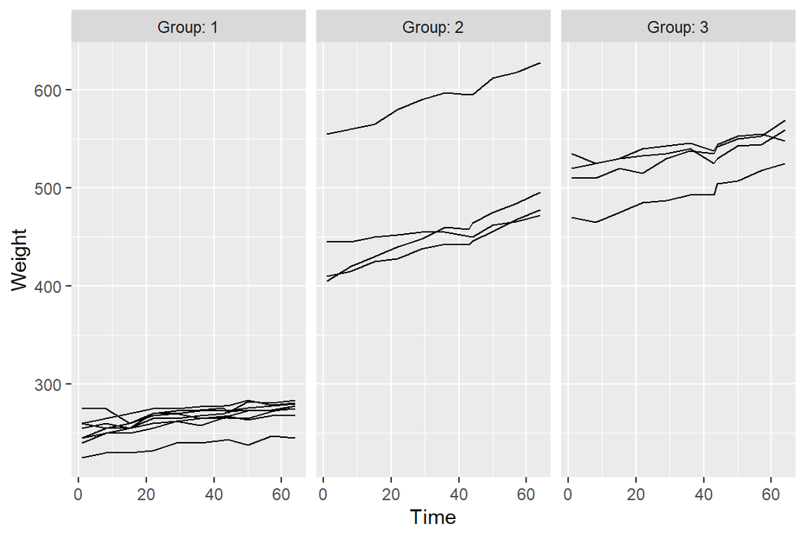

```r
#Plot the data for each group and each individual
ggplot(RATS, aes(x = Time, y = Weight, group = ID)) +
  geom_line() +
  scale_linetype_manual(values = rep(1:10, times=4)) +
  facet_grid(. ~ Group, labeller = label_both) +
  theme(legend.position = "none") +
  scale_y_continuous(limits = c(min(RATS$Weight), max(RATS$Weight)))
```

Okey, looks like that, in the group 1 the rats have been overall smaller than in groups 2 or 3. Also the group 1 includes 8 rats, and 2 and 3 only 4 each. Because the study is about how the weight is changing between weeks and not the actual weight value, it is good to standardize the values. This way it is possible to focus only on the change in weight. This can be done by subtracting the average of the weight from the original weight and dividing it by standard deviation.

```r
#Standardize the weight variable
RATS <- RATS %>%
  group_by(Time) %>%
  mutate(stdweight = (Weight - mean(Weight))/sd(Weight)) %>%
  ungroup()

#How does it look now?
glimpse(RATS)
```

```
## Rows: 176
## Columns: 6
## $ ID        <fct> 1, 2, 3, 4, 5, 6, 7, 8, 9, 10, 11, 12, 13, 14, 15, 16, 1, 2,…
## $ Group     <fct> 1, 1, 1, 1, 1, 1, 1, 1, 2, 2, 2, 2, 3, 3, 3, 3, 1, 1, 1, 1, …
## $ WD        <chr> "WD1", "WD1", "WD1", "WD1", "WD1", "WD1", "WD1", "WD1", "WD1…
## $ Weight    <dbl> 240, 225, 245, 260, 255, 260, 275, 245, 410, 405, 445, 555, …
## $ Time      <dbl> 1, 1, 1, 1, 1, 1, 1, 1, 1, 1, 1, 1, 1, 1, 1, 1, 8, 8, 8, 8, …
## $ stdweight <dbl> -1.0011429, -1.1203857, -0.9613953, -0.8421525, -0.8819001, …
```

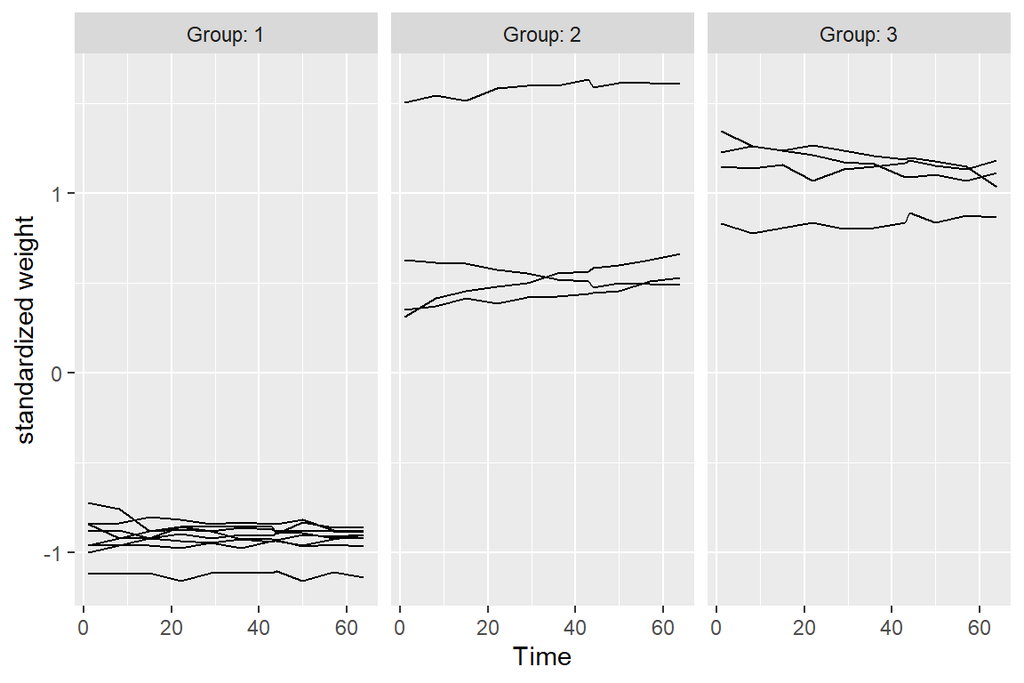

```r
#Plot the new standardized weights
ggplot(RATS, aes(x = Time, y = stdweight, group = ID)) +
  geom_line() +
  scale_linetype_manual(values = rep(1:10, times=4)) +
  facet_grid(. ~ Group, labeller = label_both) +
  scale_y_continuous(name = "standardized weight")
```

```r
# Summary data
RATS2 <- RATS %>%
  group_by(Group, Time) %>%
    summarise( mean = mean(Weight), se = (mean(Weight)/ sqrt((count = n()))))%>%
  ungroup()
# Glimpse the data
glimpse(RATS2)
```

```
## Rows: 33
## Columns: 4
## $ Group <fct> 1, 1, 1, 1, 1, 1, 1, 1, 1, 1, 1, 2, 2, 2, 2, 2, 2, 2, 2, 2, 2, 2…
## $ Time  <dbl> 1, 8, 15, 22, 29, 36, 43, 44, 50, 57, 64, 1, 8, 15, 22, 29, 36, …
## $ mean  <dbl> 250.625, 255.000, 254.375, 261.875, 264.625, 265.000, 267.375, 2…
## $ se    <dbl> 88.60932, 90.15611, 89.93514, 92.58679, 93.55907, 93.69165, 94.5…
```

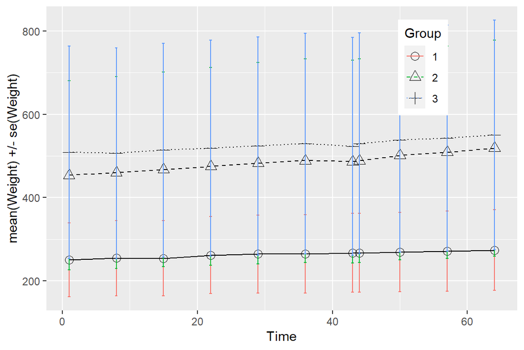

```r
# Plot the mean profiles
ggplot(RATS2, aes(x = Time, y = mean, linetype = Group, shape = Group)) +
  geom_line() +
  scale_linetype_manual(values = c(1,2,3)) +
  geom_point(size=3) +
  scale_shape_manual(values = c(1,2,3)) +
  geom_errorbar(aes(ymin=mean-se, ymax=mean+se, linetype="1", color= Group), width=0.4) +
  theme(legend.position = c(0.8,0.8)) +
  scale_y_continuous(name = "mean(Weight) +/- se(Weight)")
```